# Cardiovascular model in Section 5.2 | Simulation study

This notebook contains the code of the paper "Learning Physics between Digital Twins with Low-Fidelity Models and Physics-Informed Gaussian Processes". The models are fitted in rstan and the code is available in the folder "STAN/WK2".

#### Load packages

```r
# uncomment to install
# install.packages("rstan")
# install.packages("ggplot2")
library(rstan)
library(ggplot2)
library(latex2exp)
rstan_options(auto_write = TRUE)
options(mc.cores = 3) # allocate 3 cores (for each model we run 3 chains in parallel)

# Numerical simulator of the WK3 model
source("WK_numerical_simulators/WK2and3_sim_fn.R")
# Load flow data
d = readRDS("Data/Inflow_time.rds")
```

#### Reality and modelling choice

$$\begin{align}
\mathcal{R}: \quad & \frac{d P(t)}{d t} + \frac{P(t)}{R_2C} = \frac{Q(t)}{C} \left (1 + \frac{ R_1}{R_2} \right ) + R_1 \frac{d Q(t)}{dt} \quad \text{ (the model we use to simulate data) }\text{ [WK3] }\\
\eta: \quad & Q(t) = \frac{1}{R}P(t) + C \frac{dP(t)}{dt} \quad \text{ (the misspesified model we use to fit the data) } \text{ [WK2] }
\end{align}$$

```r
# choose some reasonable physical parameter values
R_val=c(1,1.15, 1.3); C_val = c(1.1,0.95,1.25)
RC=expand.grid(R_val,C_val) # create all possible combinations
Rtrue=RC[,1]; Ctrue=RC[,2]
Ns=length(Rtrue) # number of individuals
flow = d$inflow*0.95 # flow data
time = d$time # corresponding time
nP=12 # number of pressure data
nI=14 # number of inflow data
nc=2  # number of cardiac cycles
nflow = length(flow)
post_nnd=post_nwd=l_df_nnd=l_df_nwd=list()

set.seed(123)
Zvec=sample(seq(0.02,0.1,by=0.01), length(Rtrue), replace = T)
yP=tP=matrix(NA,nrow = Ns, ncol = nP*nc)
yI=tI=matrix(NA,nrow = Ns, ncol = nI*nc)
P_true = matrix(NA, nrow = nflow, ncol = Ns)
t1=Sys.time()
for(i in 1:Ns){
  # 1. simulate WK3 data (R=R_2, Z=R_1)
  Psim=WK3_simulate(flow = flow, time = time, R = Rtrue[i], C = Ctrue[i], Z=Zvec[i]) # simulate WK3 data for a given flow Q(t)
  P_true[,i] = Psim
  # 2. choose pressure and inflow indices
  indP = round(seq(1, nflow, length.out = nP)); indI = round(seq(1, nflow, length.out = nI))
  yP_real = Psim[indP]; yI_real = flow[indI] # noise free fimulated pressure and flow
  # 3. Add noise
  set.seed(123)
  Pnoise = rnorm(nP*nc, 0, 4) # sample pressure noise from N(0, 4^2)
  Inoise =rnorm(nI*nc, 0, 10) # sample flow noise from N(0,10^2)
  yP_real = rep(yP_real,nc) # create 2 replicates (2 cardiac cycles/heart beats)
  yI_real = rep(yI_real,nc) # create 2 replicates (2 cardiac cycles/heart beats)
  # 4. store individual data in the population matrices
  yP[i,]= yP_real + Pnoise # add noise
  yI[i,]= yI_real + Inoise # add noise
  tP[i,] = time[indP] # corresponding time (synchronized for the two cycles)
  tI[i,] = time[indI] # corresponding time (synchronized for the two cycles)
}
id=1:Ns
data_population = list(nP=nc*nP, nI=nc*nI, tP=tP, tI=tI, yP=yP, yI=yI,id=id, Ns=Ns)
```

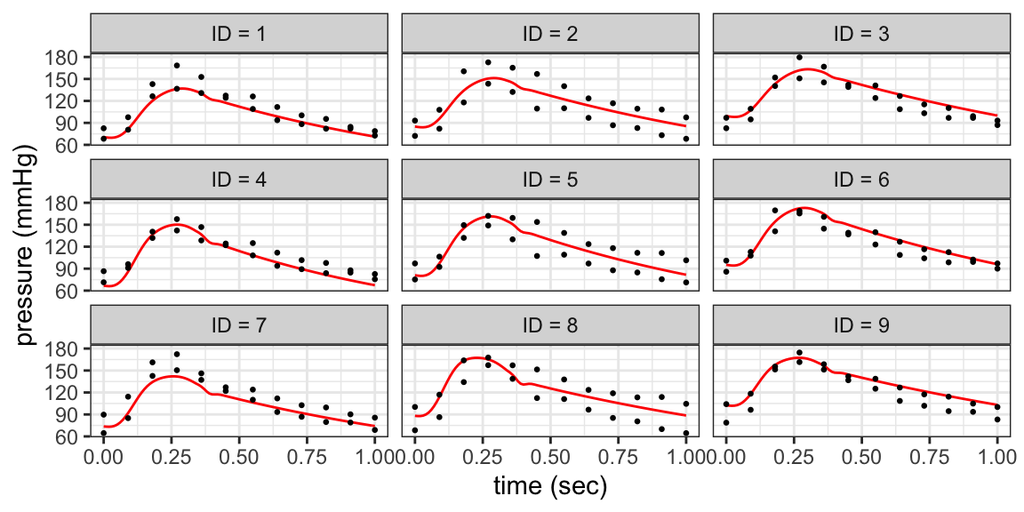

```r
ID = paste0("ID = ", 1:Ns)
df_Ptrue = data.frame(pressure = as.vector(P_true), time = rep(time,Ns), ID = rep(ID, each=nflow))
df_Pobs = data.frame(pressure = as.vector(t(yP)), time=as.vector(t(tP)), ID = rep(ID, each=nP))

ggplot()+
  geom_line(data=df_Ptrue, aes(x=time,y=pressure), color="red")+
  geom_point(data=df_Pobs, aes(x=time,y=pressure), color="black", size=0.5)+
  facet_wrap(ID~., nrow = 3)+theme_bw()+xlab("time (sec)")+ ylab("pressure (mmHg)")
```

This is the misspecified model that does not account for model discrepancy (no-without delta in paper, Figure 6). For more details on the physics-informed Gaussian process prior see Appendix E.1.

Stan code:

```r
# writeLines(readLines('STAN/WK2/WK2_nodelta.stan'))
```

We fit the model to each individual data set and we plot the trace for the last individual

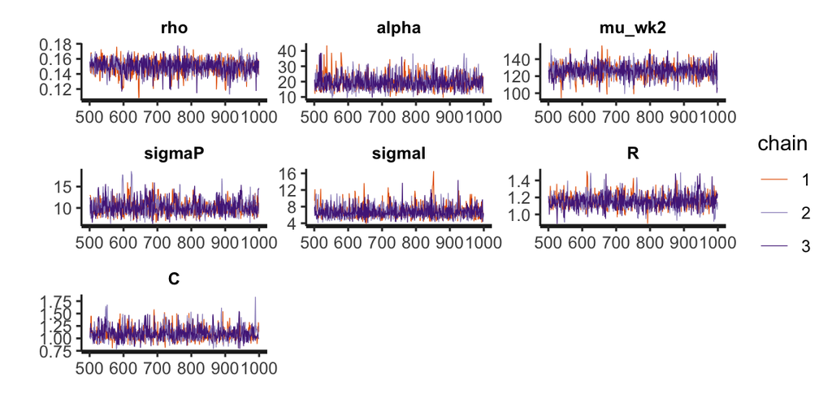

```r
#-------------------------------------------------
### Model 1 (no-without delta in paper, Figure 6)
# WK2 PI prior / no delta (magenta model)
for(i in 1:Ns){
  data_ind = list(nP=nc*nP, nI=nc*nI, tP=tP[i,], tI=tI[i,], yP=yP[i,], yI=yI[i,])
  fit_nnd= stan(file= 'STAN/WK2/WK2_nodelta.stan',
                    data=data_ind,
                    chains=3,
                    iter=1000,
                    seed=123
  )
  post_nnd[[i]]=extract(fit_nnd)
  l_df_nnd[[i]]=data.frame(extract(fit_nnd))
}
stan_trace(fit_nnd, size=0.2)
```

### Model 2 (no-with $\delta(t)$ in paper, Figure 7)

Now we account for model discrepancy $\delta_m(x_m)\sim GP(0,K_\delta(x_m,x_m')),$ where we use the squared exponential kernel $K_\delta(x_m,x_m') = \alpha_m^2 \exp\left(-\frac{(x_m-x_m')^2}{2\rho_m^2}\right).$ More details about the model are given in the Appendix E.1.

Stan code:

```r
# writeLines(readLines('STAN/WK2/WK2_delta.stan'))
```

We fit this model to each individual data set separately

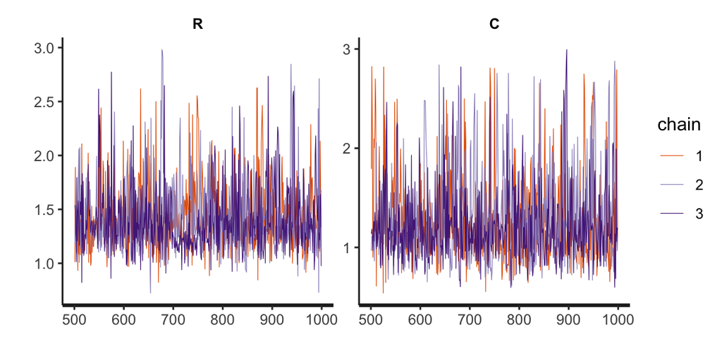

```r
# WK2 PI prior / with pressure delta (red model)
for(i in 1:Ns){
  data_ind = list(nP=nc*nP, nI=nc*nI, tP=tP[i,], tI=tI[i,], yP=yP[i,], yI=yI[i,])
  fit_nwd= stan(file= 'STAN/WK2/WK2_delta.stan', #'STAN_WK/WK_ind_delta.stan',
                          data=data_ind,
                          chains=3,
                          iter=1000,
                          seed=123
  )
  post_nwd[[i]]=extract(fit_nwd)
  l_df_nwd[[i]]=data.frame(extract(fit_nwd))
}
stan_trace(fit_nwd, size=0.2, pars = c("R", "C"))
```

### Model 3 (yes/common $\delta(t)$ in paper, Figure 7)

Stan code:

```r
# writeLines(readLines('STAN/WK2/WK2_common_delta.stan'))
```

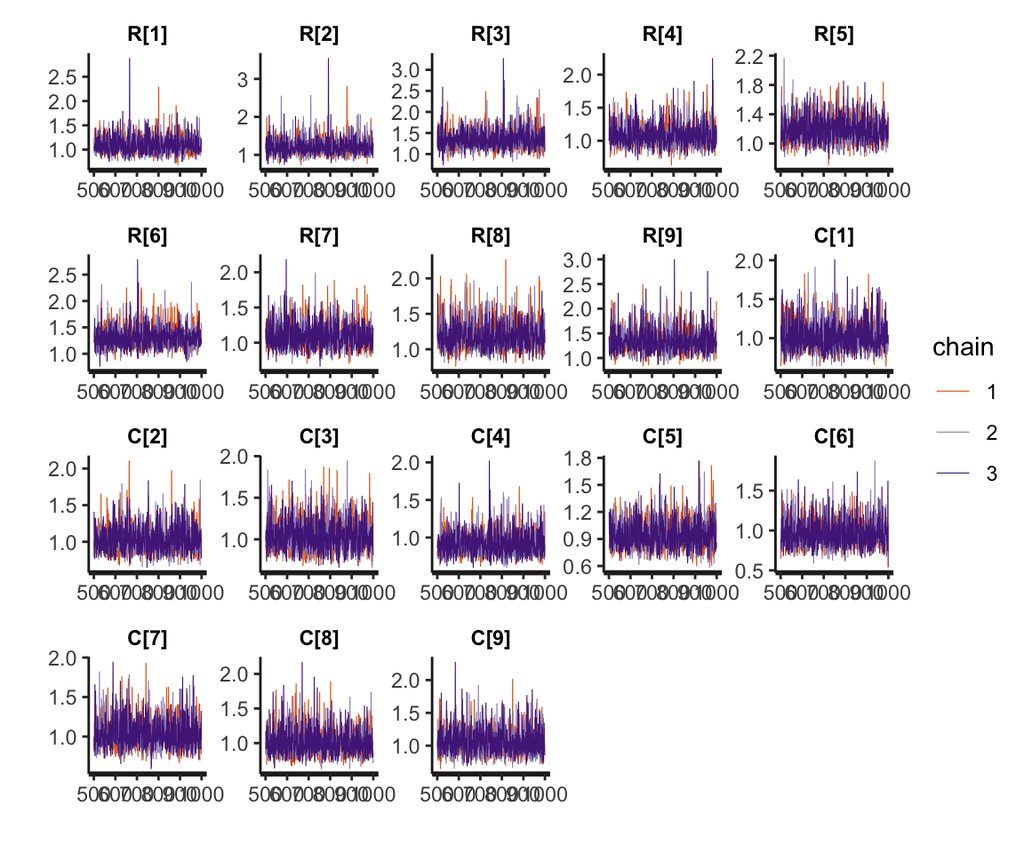

```r
#-------------------------------------------------
# shared R,C common delta (blue model)
fit_yes_common_delta = stan(file='STAN/WK2/WK2_common_delta.stan',
                            data=data_population,
                            chains=3,
                            iter=1000,
                            seed=123
)
# names(fit_yes_common_delta)
stan_trace(fit_yes_common_delta, pars = c("R","C"), size=0.2)
```

```r
ex_ycd=extract(fit_yes_common_delta)
df_ycd =data.frame(ex_ycd)
```

### Model 4 (yes/shared $\delta(t)$ in paper, Figure 7)

Stan code:

```r
# writeLines(readLines('STAN/WK2/WK2_shared_delta.stan'))
```

Model fit:

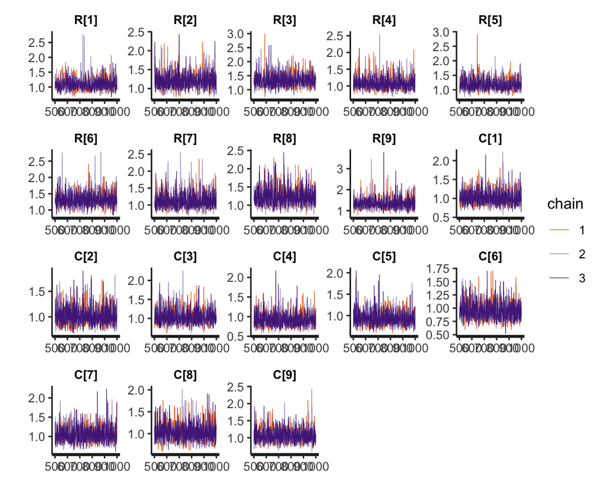

```r
#-------------------------------------------------
# shared R,C shared delta (green model)
fit_ysd = stan(file='STAN/WK2/WK2_shared_delta.stan',
                            data=data_population,
                            chains=3,
                            iter=1000,
                            seed=123
)
# names(fit_ysd)
stan_trace(fit_ysd, pars = c("R", "C"), size=0.2)
```

```r
ex_ysd=extract(fit_ysd)
df_ysd=data.frame(ex_ysd)
```

#### Plot 95% CIs for all methods (Figure 6 in the paper)

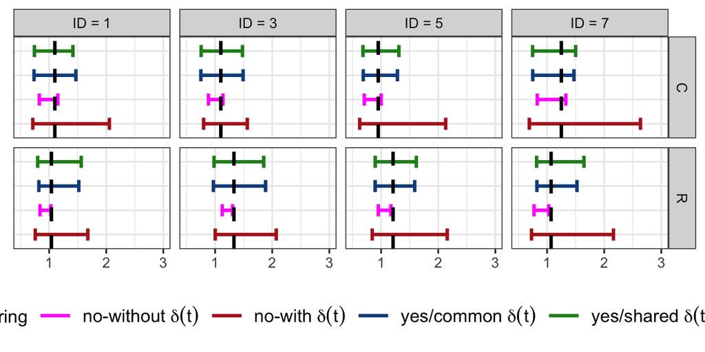

```r
ID = paste0("ID = ",1:9)
df_CIs$ID = rep(ID,8)
rid=df_CIs$id%in%c(1,3,5,7)
(pl_cis=ggplot()+
    geom_errorbar(data = df_CIs[rid,], aes(xmin=low, xmax=upper, y=sharing, color=sharing),size=1, width=0.5)+
    geom_vline(data=df_CIs[rid,] ,aes(xintercept=true),size = 1, color="black", linetype=2)+
    # geom_point(aes(x=as.factor(id),y=true))+
    facet_grid(par~ID)+theme_bw()+ylab("")+xlim(0.5,3)+#xlab("ID")+
    #scale_color_discrete(breaks=c('no without delta', 'no with delta', "yes/common delta", "yes/shared delta"))+
    scale_color_manual(
      breaks=c('no-without delta', 'no-with delta', "yes/common delta", "yes/shared delta"),
      values=c("magenta","firebrick","dodgerblue4", "forestgreen"),labels = lbl)+
  theme(
    #strip.text.x = element_text(size = 15),
    axis.title.y=element_blank(),
    axis.text.y=element_blank(),
    axis.ticks.y=element_blank(),
    legend.position="bottom",
    legend.key.size = unit(0.8, 'cm'), #change legend key size
    legend.key.height = unit(0.8, 'cm'), #change legend key height
    legend.key.width = unit(0.8, 'cm'), #change legend key width
    legend.title = element_text(size=11), #change legend title font size
    legend.text = element_text(size=11),
    axis.title.x = element_text(size=11))
  )
```

```r
# ggsave("Figs/wk_sim_cis_new.pdf", plot = pl_cis, width = 17, height = 8.5, units = "cm")
```

#### Uncertainty reduction

```r
df_red=df_CIs[df_CIs$sharing == "no-with delta" | df_CIs$sharing == "yes/common delta" | df_CIs$sharing == "yes/shared delta",]
df_red_C = df_red[df_red$par=="C",]
df_red_C$dif = df_red_C$upper-df_red_C$low

methd=c("no-with delta", "yes/common delta",  "yes/shared delta")
red_common = (df_red_C$dif[df_red_C$sharing == methd[1]] - df_red_C$dif[df_red_C$sharing == methd[2]])/ df_red_C$dif[df_red_C$sharing == methd[1]]
red_shared = (df_red_C$dif[df_red_C$sharing == methd[1]] - df_red_C$dif[df_red_C$sharing == methd[3]])/ df_red_C$dif[df_red_C$sharing == methd[1]]
mu_lu_fn = function(df) c(mu = mean(df), lower=min(df), upper=max(df))
# mu_lu_fn(red_common)
# mu_lu_fn(red_shared)
res_C = data.frame(common = as.vector(mu_lu_fn(red_common)), shared = as.vector(mu_lu_fn(red_shared)))
rownames(res_C) = c("mean", "low", "upper")

df_red_R = df_red[df_red$par=="R",]
df_red_R$dif = df_red_R$upper-df_red_R$low

red_common = (df_red_R$dif[df_red_R$sharing == methd[1]] - df_red_R$dif[df_red_R$sharing == methd[2]])/ df_red_R$dif[df_red_R$sharing == methd[1]]
red_shared = (df_red_R$dif[df_red_R$sharing == methd[1]] - df_red_R$dif[df_red_R$sharing == methd[3]])/ df_red_R$dif[df_red_R$sharing == methd[1]]
mu_lu_fn = function(df) c(mu = mean(df), lower=min(df), upper=max(df))
# mu_lu_fn(red_common)
# mu_lu_fn(red_shared)
res_R = data.frame(common = as.vector(mu_lu_fn(red_common)), shared = as.vector(mu_lu_fn(red_shared)))
rownames(res_R) = c("mean", "low", "upper")
res_RC = list(R=res_R, C=res_C)
# saveRDS(res_RC, file = "Data/reduction_WK_sim.rds")
```